# hydrograph

Wenlong

4/15/2018

对于水文工作者来说，降雨-水文过程线图是最基础的数据展示方式，能够制作一张符合要求的水文过程线图(hydrograph)是一项必备技能。笔者今天简要介绍一下降雨-水文过程线图，然后着重介绍几种常用的图表制作软件和制作过程。

## 1. 降雨水文过程线图介绍

**现在科学的核心假定之一是质量守恒与能量守恒定律 (mass balance). 在水文学中，质量守恒的体现形式之一就是水循环，包括全球大循环与区域小循环。**对于全球大循环，海洋的中通过蒸发进入大气层，然后运移到大陆形成降水；降水汇集到河道形成径流，最后在流入海洋。当我们研究河流时，一般认为水文过程是降水驱动的。因此，我们经常讲降雨和水文过程画在一起，形成降雨-水文过程线图。

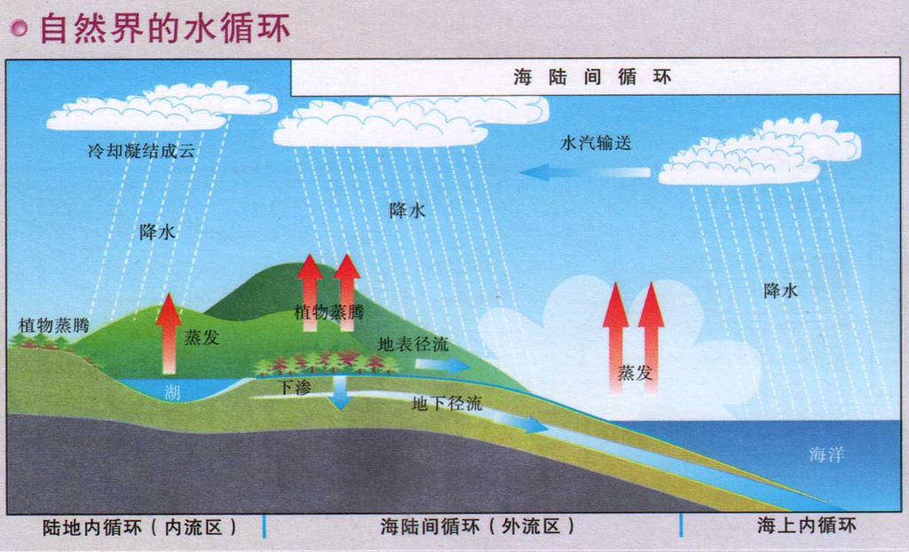

Fig.1 全球水循环示意图

Fig.2 是一张典型的降雨(precipitation) - 水文过程线图(Hydrograph)。习惯上，我们将x轴设置为时间轴，例如小时，天数或者月份等等；y轴设置为径流量，单位为立方米每秒，有时候也会用深度的概念，即所有径流量铺在相应面积上的水层厚度来表示水量。需要注意的是，很多水文学工作者倾向于将降水设置为柱状图，倒过来放在水文过程的上方。这种构图首先展示了该水文过程是相应降水驱动的，其次要能够表征一些参数，例如洪峰滞时(Fig. 2中的Lag)既是降雨中心至洪峰出现的时间。

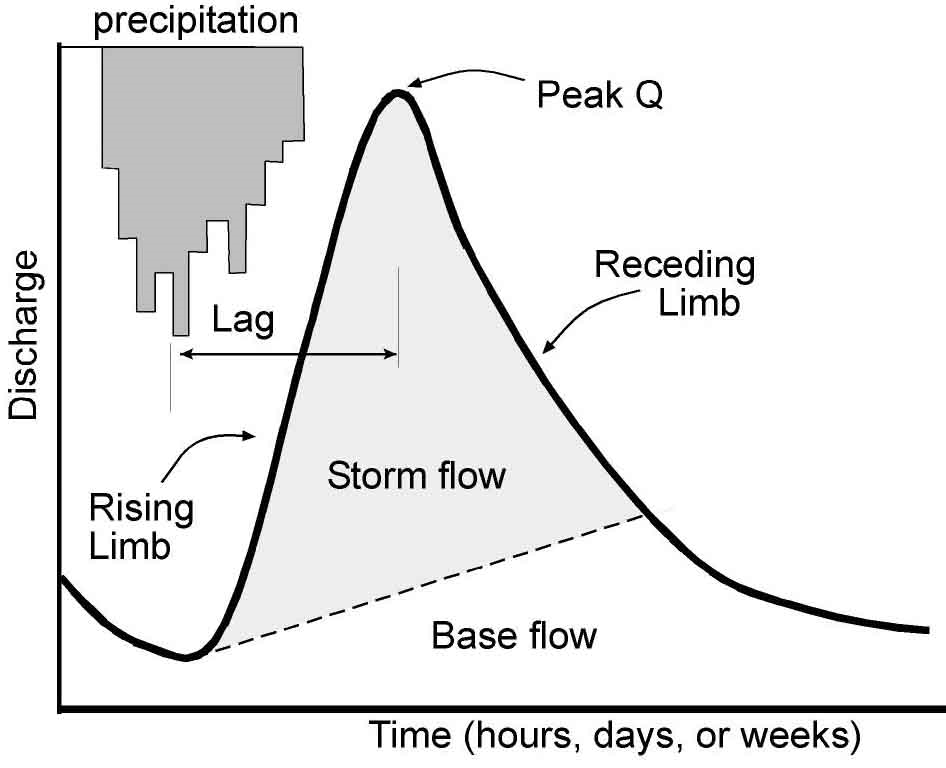

Fig. 2 降雨水文过程示意图

## 2. 降水-水文过程线图制作方法

降水-水文过程线图的制作方法其实特别简单，只需要以下步骤即可：

- 整理降水数据和径流数据，保证两者之间时间轴相同；
- 将径流数据设置成折线图或者散点图；
- 将降水数据设置成柱状图，投影到y轴副坐标轴，并反转坐标轴；
- 调整坐标轴的数据展示范围，以保证降水和径流数据图没有重叠。

以下笔者将展示不同软件的做法， 包括MS Excel, ggplot2 in R, matplotlib in Python, etc.

### 2.1 MS Excel

MS Excel 是大家非常熟悉的数据分析与可视化软件，其功能强大，操作也较为直观和简单。用Excel制作水文过程线图的关键点是将降雨放置在副坐标轴，同时翻转副坐标轴。具体的步骤如下所示：

1. 把降雨数据和流量数据放入同一张图表；
2. 将降雨数据设置在y轴的副坐标轴，并翻转坐标轴；
3. 设置降雨数据为柱状图，流量数据为散点图(或者折线图)；
4. 如果两组数据之间没有对齐，检查x轴的起始与结束时间是否正确；
5. 调整两个y轴的最大值，保证两组数据之间没有重合。

最后的结果如Fig. 3所示，详细的数据及制作方法可以从[这里](https://github.com/wenlong-liu/wechat_blogs/blob/master/data/sample_data.xlsx)下载.

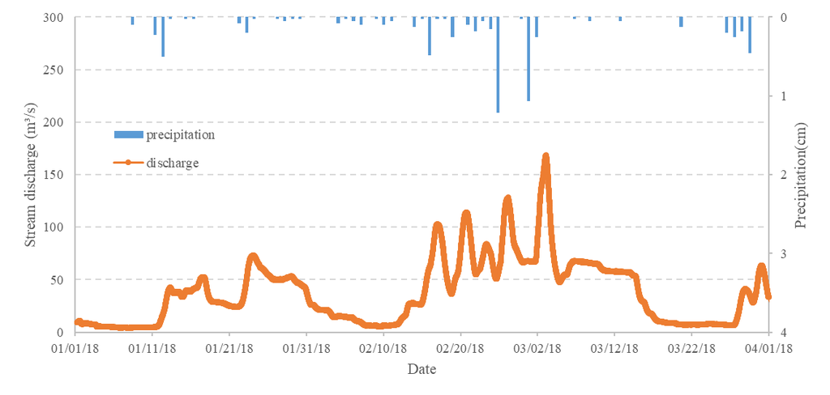

Fig. 3 Excel 制作水文过程线图示例 (Data source: USGS)

### 2.2 highcharter in R

highcharter 提供了Highcharts的R接口。Highchart是一款基于JavaScript的绘图库，可以用来制作多种类型的图表。由于图表渲染较慢，本文中将15min的数据综合为逐日数据。具体代码如下所示。

```r
# load required libraries and data.
require(highcharter)
require(tidyverse)
# for local data.
hydrology_data = read_csv("../data/sample_data.csv")
# down scaling to daily data.
hydrology_daily = hydrology_data %>%
  mutate(date = as.Date(format(dateTime, '%Y-%m-%d'))) %>%
  select(-dateTime) %>%
  group_by(date) %>%
  summarise(precipitation = sum(precipitation, na.rm = TRUE),
            discharge = mean(discharge, na.rm = TRUE))

#plot hydrograph and precipitation.
hydrograph <- highchart() %>%
hc_yAxis_multiples(list(title = list(text = "Precipitation (cm)"), reversed = TRUE, opposite = TRUE, max = 10),
                   list(title = list(text = "Discharge  (m3/s)"), max = 200)) %>%
hc_add_series(name = "Precipitation", data = hydrology_daily$precipitation, type = "column" ) %>%
hc_add_series(name = "Stream discharge", data = hydrology_daily$discharge, type = "spline", yAxis = 1) %>%
hc_xAxis(categories = hydrology_daily$date, title = list(text = "Date"))

htmltools::tagList(hydrograph)
```

[output not shown]

### 2.3 ggplot2 in R

ggplot2 是R中一款非常流行且强大的数据可视化工具。 ggplot2常年在所有R包的下载榜中名列前茅。对于笔者来说，ggplot2最大的用处就治愈了笔者的直男审美(汗。)。鉴于ggplot2的开发团队不太喜欢次坐标轴的做法，我们可以用facet plots来制作水文过程线图。

由于ggplot2中所有的facet需要统一的图表格式，为了满足section 1中的要求，我们需要稍微变化一下图表的制作方式，具体内容如下：

- 利用dplyr::filter 的方法来制作不同的facet, 这样就可以在不同的facet中画出不同的图表；
- 利用facet的标签来替代y坐标轴标题；
- 将数据格式从宽型（wide) 转换成长型(long)；
- 将参数因子化并设置为不同的因素水平(level),这样即可对facet进行排序。

详细代码如下：

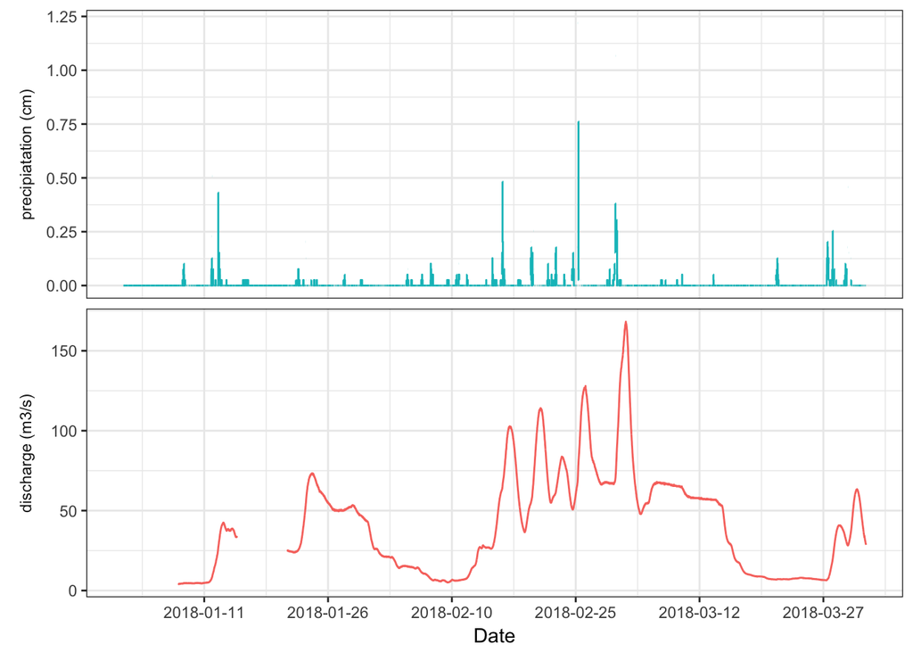

```r
require(tidyverse)

# for local data.
hydrology_data = read_csv("../data/sample_data.csv")

# change wide data to long data.
hydrology_data = hydrology_data %>%
  mutate( "precipiatation (cm)" = precipitation,
          "discharge (m3/s)" = discharge) %>%
  gather(variable, values, c("precipiatation (cm)", "discharge (m3/s)")) %>%
  mutate(variable = factor(variable, levels = c("precipiatation (cm)", "discharge (m3/s)")))

# plot data.
# plot separately using filter to change different figure format.
f1 = ggplot(hydrology_data, aes(x = dateTime, y = values, color=variable))+
facet_wrap(~variable, scale='free_y', nrow = 2, strip.position = "left")
f2 = f1 + geom_step(data  = filter(hydrology_data, variable == "precipiatation (cm)"))
f3 = f2 +  geom_line(data = filter(hydrology_data, variable == "discharge (m3/s)"))

# update graph format.
f3+theme_bw()+
  theme(legend.position = "none")+
  ylab(NULL)+
  theme(strip.background = element_blank(),
           strip.placement = "outside")+
  scale_x_datetime(name = "Date", date_breaks = "15 day")
```

Fig.5 使用ggplot2绘制水文过程线图

# 3 Take-home points

- 水文过程线图是水文学研究的基础，需要熟练掌握相应制图技术；
- 本文中介绍了数种制作科技论文配图的方法；
- 本文中的用R制图的代码均为reproducible output, 读者可以登录[my rep](https://github.com/wenlong-liu/wechat_blogs)查看和调试代码。

The end. Thanks for reading.